# Predicting Barbell Lifts

Annie Flippo

October 14, 2014

# Executive Summary

Human wearable devices have increased dramatically in the past few years. These devices have made it possible to collect large amount of data in human activities. In this study, the data collected in the Qualitative Activity Recognition of Weight Lifting Exercises project (see reference below) were used to categorgized barbell lifts. The participants were asked to perform to lift in one correct and four incorrect manners. These were categorized in the five following classes:

- Class A - exactly according to the specification
- Class B - throwing the elbows to the front
- Class C - lifting the dumbbell only halfway
- Class D - lowering the dumbbell only halfway
- Class E - throwing the hips to the front

## Get the Data

```r
library(caret); library(e1071); library(ggplot2);library(corrgram);library(doSNOW);
registerDoSNOW(makeCluster(2, type = "SOCK"))
setwd("~/Dropbox/Coursera_MachineLearning")
if (!file.exists("pml-training.csv")) {
    trainURL <- "https://d396qusza40orc.cloudfront.net/predmachlearn/pml-training.csv"
    testURL <- "https://d396qusza40orc.cloudfront.net/predmachlearn/pml-testing.csv"
    download.file(trainURL, destfile="pml-training.csv", method="curl")
    download.file(testURL, destfile="pml-testing.csv", method="curl")
}
train.raw <- read.csv("pml-training.csv")
test.raw <- read.csv("pml-testing.csv")
```

## Data Preparation

Many columns have missing data or zero-length string. Since missing values do not contribute to the model, they are excluded in the data set. In addition, names of participants and dates are also eliminated. Columns with more than 90% of missing data or zero-length string were removed from the study. Finally, the data was partitioned 70% for training and 30% for validation as follows.

```r
set.seed(123456)
inTrain = createDataPartition(train.raw$classe, p = 0.7)[[1]]
# Find columns with mostly NAs and keep only columns with more than 90% of data
nonNAcolumn <- (apply(train.raw, 2, function(x) sum(!is.na(x)))) > (nrow(train.raw) * 0.9)

# Find columns with mostly data and keep only columns that are more than 90% non-blanks
nonBlankColumn <- (apply(train.raw, 2, function(x) sum(nchar(x) != 0))) > (nrow(train.raw) * 0.9)
columnsToKeep <- nonNAcolumn & nonBlankColumn

# Include only columns that has data
training <- train.raw [, columnsToKeep]
# Remove first 5 columns of name and dates
training <- training [, 6:ncol(training)]

train.data <- training[inTrain,]
validate.data <- training[-inTrain,]
test.data <- test.raw[, columnsToKeep]
test.data <- test.data[, 6:ncol(test.data)]
```

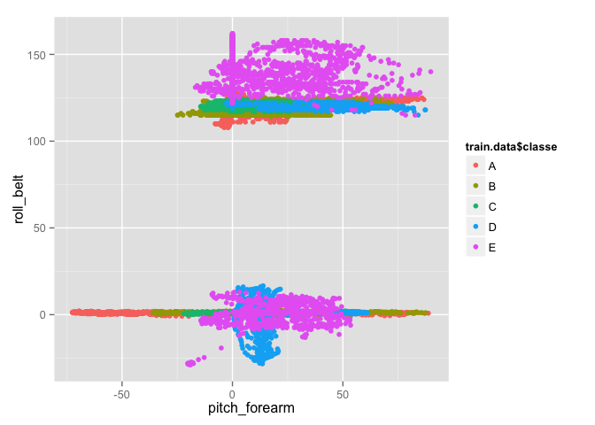

```r
p <- ggplot(train.data, aes(pitch_forearm, roll_belt))
p + geom_point(aes(colour=train.data$classe))
```

## Modeling

A Random Forest algorithm is run for the training data.

```r
set.seed(123456)
system.time(
modelFit <- train(classe ~., data=train.data, method="rf", importance=TRUE,
                  trControl = trainControl(method = "cv", number = 4))
)
```

```
##    user  system elapsed
##  93.546   0.304 512.555
```

```r
print(modelFit$finalModel)
```

```
##
## Call:
##  randomForest(x = x, y = y, mtry = param$mtry, importance = TRUE)
##                Type of random forest: classification
##                      Number of trees: 500
## No. of variables tried at each split: 28
##
##         OOB estimate of  error rate: 0.22%
## Confusion matrix:
##      A    B    C    D    E class.error
## A 3905    0    0    0    1    0.000256
## B    7 2648    3    0    0    0.003762
## C    0    4 2391    1    0    0.002087
## D    0    0    8 2243    1    0.003996
## E    0    0    0    5 2520    0.001980
```

With the In-Sample error rate is 0.22%, I **expect the Out-of-Sample error rate to be slight higher than 0.22%**. As the number of trees increases, the error rate decreases as illustrated by the following graph:

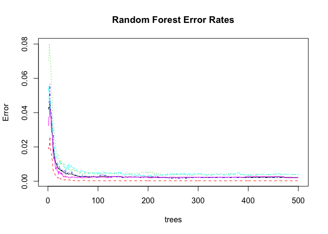

A Variable Importance graph for the model per classe of barbell lifts:

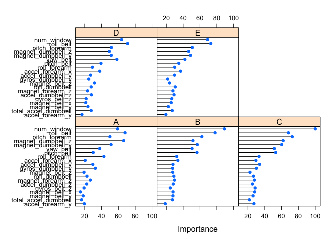

## Validating the Model

The modelFit object was used to predict the outcome classe for the validation data set aside earlier. The accuracy for the predictions in the validation data is 0.997 which gives an error rate of 0.003 (or 0.3%).

```r
# Using Validate data set aside
predValue <- predict(modelFit, validate.data)
confusionMatrix(predValue,validate.data$classe)
```

```
## Confusion Matrix and Statistics
##
##           Reference
## Prediction    A    B    C    D    E
##          A 1674    7    0    0    0
##          B    0 1132    2    0    0
##          C    0    0 1024    4    0
##          D    0    0    0  960    3
##          E    0    0    0    0 1079
##
## Overall Statistics
##
##                Accuracy : 0.997
##                  95% CI : (0.996, 0.998)
##     No Information Rate : 0.284
##     P-Value [Acc > NIR] : <2e-16
##
##                   Kappa : 0.997
##  Mcnemar's Test P-Value : NA
##
## Statistics by Class:
##
##                      Class: A Class: B Class: C Class: D Class: E
## Sensitivity             1.000    0.994    0.998    0.996    0.997
## Specificity             0.998    1.000    0.999    0.999    1.000
## Pos Pred Value          0.996    0.998    0.996    0.997    1.000
## Neg Pred Value          1.000    0.999    1.000    0.999    0.999
## Prevalence              0.284    0.194    0.174    0.164    0.184
## Detection Rate          0.284    0.192    0.174    0.163    0.183
## Detection Prevalence    0.286    0.193    0.175    0.164    0.183
## Balanced Accuracy       0.999    0.997    0.999    0.998    0.999
```

## Prediction on test data

In the final project submission, I predicted the classe for 20 test cases.

```r
# Predicting using test data set
predTestValue <- predict(modelFit, test.data)
predTestValue
```

```
##  [1] B A B A A E D B A A B C B A E E A B B B
## Levels: A B C D E
```

## Conclusion

### References

Velloso, E.; Bulling, A.; Gellersen, H.; Ugulino, W.; Fuks, H. Qualitative Activity Recognition of Weight Lifting Exercises. Proceedings of 4th International Conference in Cooperation with SIGCHI (Augmented Human ’13) . Stuttgart, Germany: ACM SIGCHI, 2013.

Read more: http://groupware.les.inf.puc-rio.br/har#weight_lifting_exercises#ixzz3GXgmffpY